# Chipseq_test

ms

13 July,2016

## Test Markdown by MS for CHIPseq turorial

MS generates his first markdown ;)

```r
library(EpigeneticsCSAMA)
dataDirectory =  system.file("bedfiles", package="EpigeneticsCSAMA")
dataDirectory
```

```
## [1] "/Library/Frameworks/R.framework/Versions/3.3/Resources/library/EpigeneticsCSAMA/bedfiles"
```

## 3 Reading the filtered ChIP-seq reads

```r
library(GenomicRanges)
library(rtracklayer)
library(IRanges)

input = import.bed(file.path(dataDirectory, 'ES_input_filtered_ucsc_chr6.bed'))
rep1 = import.bed(file.path(dataDirectory, 'H3K27ac_rep1_filtered_ucsc_chr6.bed'))
rep2 = import.bed(file.path(dataDirectory, 'H3K27ac_rep2_filtered_ucsc_chr6.bed'))
```

The objects input, rep1 and rep2 hold the genomic annotation of the filtered reads for the input sample and ChIP-seq replicate 1 and replicate 2, respectively. We display the rep1 object. We see that the strand information, read name along with alignment score are included as information for each read.

```r
rep1
```

```
## GRanges object with 481412 ranges and 2 metadata columns:
##            seqnames                 ranges strand |               name
##               <Rle>              <IRanges>  <Rle> |        <character>
##        [1]     chr6 [ 85222462,  85222497]      - |      SRR066766.303
##        [2]     chr6 [134189439, 134189474]      + |      SRR066766.374
##        [3]     chr6 [ 47920826,  47920861]      + |      SRR066766.393
##        [4]     chr6 [143565148, 143565183]      + |      SRR066766.397
##        [5]     chr6 [ 39392692,  39392727]      - |      SRR066766.438
##        ...      ...                    ...    ... .                ...
##   [481408]     chr6 [ 86800209,  86800244]      - | SRR066766.14657325
##   [481409]     chr6 [ 91422497,  91422532]      - | SRR066766.14657340
##   [481410]     chr6 [ 54433776,  54433811]      + | SRR066766.14657362
##   [481411]     chr6 [120020286, 120020321]      - | SRR066766.14657382
##   [481412]     chr6 [ 85113322,  85113357]      - | SRR066766.14657387
##                score
##            <numeric>
##        [1]        40
##        [2]        42
##        [3]        42
##        [4]        42
##        [5]        42
##        ...       ...
##   [481408]        42
##   [481409]        42
##   [481410]        42
##   [481411]        42
##   [481412]        42
##   -------
##   seqinfo: 1 sequence from an unspecified genome; no seqlengths
```

```r
length(input)
```

```
## [1] 465823
```

```r
length(rep1)
```

```
## [1] 481412
```

```r
length(rep2)
```

```
## [1] 506287
```

The reads correspond to sequences at the end of each IP-ed fragment (single-end sequencing data). We need to extend these reads in order to represent each IP-ed DNA fragment.

We estimate the mean read length using the estimate.mean.fraglen function from chipseq packege. Next, we extend the reads to the inferred read length using the resize function. We remove any reads for which the coordinates, after the extension, exceed chromosome length. These three analysis steps are wrapped in a single function prepareChIPseq function which we define below.

## 4 Preparation of the ChIP-seq and control samples: read extension

```r
library(chipseq)
prepareChIPseq = function(reads){
    frag.len = median( estimate.mean.fraglen(reads) )
    cat( paste0( 'Median fragment size for this library is ', round(frag.len)))
    reads.extended = resize(reads, width = frag.len)
    return( trim(reads.extended) )
}
```

We next apply it to the input and ChIP-seq samples.

```r
input = prepareChIPseq( input )
```

```
## Median fragment size for this library is 236
```

```r
rep1 = prepareChIPseq( rep1 )
```

```
## Median fragment size for this library is 122
```

```r
rep2 = prepareChIPseq( rep2 )
```

```
## Median fragment size for this library is 107
```

Compare with above to see how rep1 has changed.

```r
rep1
```

```
## GRanges object with 481412 ranges and 2 metadata columns:
##            seqnames                 ranges strand |               name
##               <Rle>              <IRanges>  <Rle> |        <character>
##        [1]     chr6 [ 85222376,  85222497]      - |      SRR066766.303
##        [2]     chr6 [134189439, 134189560]      + |      SRR066766.374
##        [3]     chr6 [ 47920826,  47920947]      + |      SRR066766.393
##        [4]     chr6 [143565148, 143565269]      + |      SRR066766.397
##        [5]     chr6 [ 39392606,  39392727]      - |      SRR066766.438
##        ...      ...                    ...    ... .                ...
##   [481408]     chr6 [ 86800123,  86800244]      - | SRR066766.14657325
##   [481409]     chr6 [ 91422411,  91422532]      - | SRR066766.14657340
##   [481410]     chr6 [ 54433776,  54433897]      + | SRR066766.14657362
##   [481411]     chr6 [120020200, 120020321]      - | SRR066766.14657382
##   [481412]     chr6 [ 85113236,  85113357]      - | SRR066766.14657387
##                score
##            <numeric>
##        [1]        40
##        [2]        42
##        [3]        42
##        [4]        42
##        [5]        42
##        ...       ...
##   [481408]        42
##   [481409]        42
##   [481410]        42
##   [481411]        42
##   [481412]        42
##   -------
##   seqinfo: 1 sequence from an unspecified genome; no seqlengths
```

# 5 Binning the ChIP-seq and control

The next step in the analysis is to count how many reads map to each of the pre-established genomic intervals (bins).

### 5.1 Generation of bins

We will tile the genome into non-overlapping bins of size 200 bp. To this end we need the information about chromosome sizes in the mouse genome (assembly mm9). In the data package, we provide the object si (strand information), which holds these data. The reader can find the code necessary to create the si object in the Obtaining si* object for *mm9** of the Appendix.

```r
data(si)
si
```

```
## Seqinfo object with 21 sequences from mm9 genome:
##   seqnames seqlengths isCircular genome
##   chr1      197195432      FALSE    mm9
##   chr2      181748087      FALSE    mm9
##   chr3      159599783      FALSE    mm9
##   chr4      155630120      FALSE    mm9
##   chr5      152537259      FALSE    mm9
##   ...             ...        ...    ...
##   chr17      95272651      FALSE    mm9
##   chr18      90772031      FALSE    mm9
##   chr19      61342430      FALSE    mm9
##   chrX      166650296      FALSE    mm9
##   chrY       15902555      FALSE    mm9
```

Next, we use the tileGenome function from the GenomicRanges package to generate a GRanges object with intervals covering the genome in tiles (bins) of size of 200 bp.

```r
binsize = 200
bins = tileGenome(si['chr6'], tilewidth=binsize,
                  cut.last.tile.in.chrom=TRUE)
bins
```

```
## GRanges object with 747586 ranges and 0 metadata columns:
##            seqnames                 ranges strand
##               <Rle>              <IRanges>  <Rle>
##        [1]     chr6            [  1,  200]      *
##        [2]     chr6            [201,  400]      *
##        [3]     chr6            [401,  600]      *
##        [4]     chr6            [601,  800]      *
##        [5]     chr6            [801, 1000]      *
##        ...      ...                    ...    ...
##   [747582]     chr6 [149516201, 149516400]      *
##   [747583]     chr6 [149516401, 149516600]      *
##   [747584]     chr6 [149516601, 149516800]      *
##   [747585]     chr6 [149516801, 149517000]      *
##   [747586]     chr6 [149517001, 149517037]      *
##   -------
##   seqinfo: 1 sequence from mm9 genome
```

### 5.2 Binning

We now count how many reads fall into each bin. For this purpose, we define the function BinChIPseq. It takes two arguments, reads and bins which are GRanges objects.

```r
BinChIPseq = function( reads, bins ){

       mcols(bins)$score = countOverlaps( bins, reads )
       return( bins )
}
```

Now we apply it to the objects input, rep1 and rep2. We obtain input.200bins, rep1.200bins and rep2.200bins, which are GRanges objects that contain the binned read coverage of the input and ChIP-seq experiments.

```r
input.200bins = BinChIPseq( input, bins )
rep1.200bins = BinChIPseq( rep1, bins )
rep2.200bins = BinChIPseq( rep2, bins )

rep1.200bins
```

```
## GRanges object with 747586 ranges and 1 metadata column:
##            seqnames                 ranges strand |     score
##               <Rle>              <IRanges>  <Rle> | <integer>
##        [1]     chr6            [  1,  200]      * |         0
##        [2]     chr6            [201,  400]      * |         0
##        [3]     chr6            [401,  600]      * |         0
##        [4]     chr6            [601,  800]      * |         0
##        [5]     chr6            [801, 1000]      * |         0
##        ...      ...                    ...    ... .       ...
##   [747582]     chr6 [149516201, 149516400]      * |         0
##   [747583]     chr6 [149516401, 149516600]      * |         0
##   [747584]     chr6 [149516601, 149516800]      * |         0
##   [747585]     chr6 [149516801, 149517000]      * |         0
##   [747586]     chr6 [149517001, 149517037]      * |         0
##   -------
##   seqinfo: 1 sequence from mm9 genome
```

We can plot coverage for 1000 bins, starting from bin 200,000.

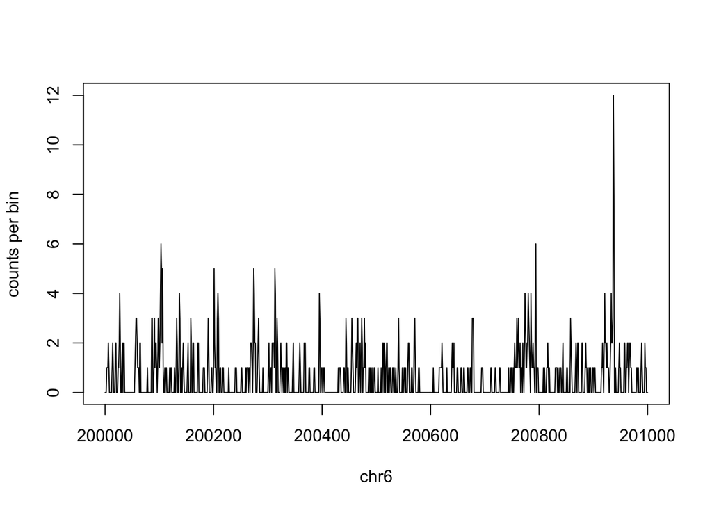

```r
plot( 200000:201000, rep1.200bins$score[200000:201000],
   xlab="chr6", ylab="counts per bin", type="l")
```

Below, we will see more sophisticated ways of plotting coverage.

### 5.3 Exporting binned data

At this step of the analysis, the data is ready to be visualized and shared. One of the most common means of sharing ChIP-seq data is to generate .wig, .binWig or .bedGraph files. They are memory and size-efficient files holding the information about the signal along the genome. Moreover, these files can be visualized in genome browsers such as IGV and IGB. We show how to export the binned data as a .bedGraph file.

```r
export(input.200bins,
       con='input_chr6.bedGraph',
       format = "bedGraph")
export(rep1.200bins,
       con='H3K27ac_rep1_chr6.bedGraph',
       format = "bedGraph")
export(rep2.200bins,
       con='H3K27ac_rep2_chr6.bedGraph',
       format = "bedGraph")
```

# 6 Visualisation of ChIP-seq data wit Gviz

Now, we have data which we would like to display along the genome. R offers a flexible infrastructure for visualisation of many types of genomics data. Here, we use the Gviz package for these purposes.

```r
library(Gviz)
```

The principle of working with Gviz relies on the generation of tracks which can be, for example ChIP-seq signal along the genome, ChIP-seq peaks, gene models or any kind of other data such as annotation of CpG islands in the genome. We start with loading the gene models for chromosome 6 starting at position 122,530,000 and ending at position 122,900,000. We focus on this region as it harbors the Nanog gene, which is stongly expressed in ES cells.

We obtain the annotation using biomaRt package. Work with biomaRt package relies on querying the biomart database. In the Appendix, we show how to obtain gene models for protein coding genes for the archive mouse genome assembly (mm9) and how to generate the bm object holding the annotation of all the RefSeq genes.

```r
data(bm)
bm
```

```
## GeneRegionTrack 'RefSeq'
## | genome: mm9
## | active chromosome: chr6
## | annotation features: 102
```

We include the GenomeAxisTrack object which is a coordinate axis showing the genomic span of the analyzed region.

```r
AT = GenomeAxisTrack( )
```

We plot the result using the plotTracks function. We choose the region to zoom into with the from and to arguments. The transcriptAnnotation argument allows to put the gene symbols in the plot.

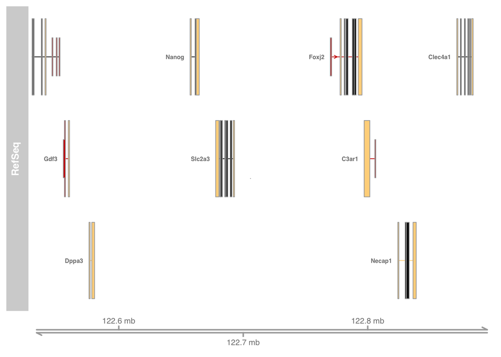

```r
plotTracks(c( bm, AT),
           from=122530000, to=122900000,
           transcriptAnnotation="symbol", window="auto",
           cex.title=1, fontsize=10 )
```

We next add our two data tracks to the plot. We first generate DataTrack objects with DataTrack function. We include the information about how the track is be labaled and colored. We obtain input.track, rep1.track and rep2.track objects.

```r
input.track = DataTrack(input.200bins,
                        strand="*", genome="mm9", col.histogram='gray',
                        fill.histogram='black', name="Input", col.axis="black",
                        cex.axis=0.4, ylim=c(0,150))

rep1.track = DataTrack(rep1.200bins,
                        strand="*", genome="mm9", col.histogram='steelblue',
                        fill.histogram='black', name="Rep. 1", col.axis='steelblue',
                        cex.axis=0.4, ylim=c(0,150))

rep2.track = DataTrack(rep2.200bins,
                        strand="*", genome="mm9", col.histogram='steelblue',
                        fill.histogram='black', name="Rep. 2", col.axis='steelblue',
                        cex.axis=0.4, ylim=c(0,150))
```

Finally, we plot these tracks along with the genomic features. We observe a uniform coverage in the case of the input track and pronounced peaks of enrichment H3K27ac in promoter and intergenic regions. Importantly, H3K27ac enriched regions are easily identified.

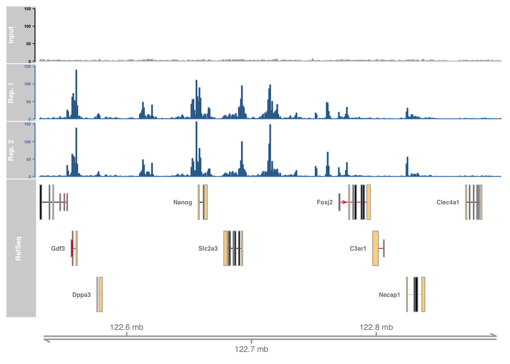

```r
plotTracks(c(input.track, rep1.track, rep2.track, bm, AT),
           from=122530000, to=122900000,
           transcriptAnnotation="symbol", window="auto",
           type="histogram", cex.title=0.7, fontsize=10 )
```

# 7 ChIP-seq peaks

ChIP-seq experiments are designed to isolate regions enriched in a factor of interest. The identification of enriched regions, often refered to as peak finding, is an area of research by itself. There are many algorithms and tools used for peak finding. The choice of a method is strongly motivated by the kind of factor analyzed. For instance, transcription factor ChIP-seq yield well defined narrow peaks whereas histone modifications ChIP-seq experiments such as H3K36me3 yield extended regions of high coverage. Finally, ChIP-seq with antobodies recognizing polymerase II result in narrow peaks combined with extended regions of enrichment.

## 7.1 Identification of peaks

As we saw in the previous section of the tutorial, H3K27ac mark shows well defined peaks. In such a case, MACS is one of the most commonly used software for peak finding. ChIP-seq peak calling can also be done in R with the BayesPeak package. However, we stick here to the most common approach and use MACS. We ran MACS for you and provide the result in the data package. You can find the code necessary to obtain the peaks in the Appendix of the vignette.

## 7.2 Peaks – basic analysis in R

We next import the .bed files of the isolated peaks from the data package.

```r
peaks.rep1 = import.bed(file.path(dataDirectory,'Rep1_peaks_ucsc_chr6.bed'))
peaks.rep2 = import.bed(file.path(dataDirectory,'Rep2_peaks_ucsc_chr6.bed'))
```

First step in the analysis of the identified peaks is to simply display them in the browser, along with the ChIP-seq and input tracks. To this end, we use AnnotationTrack function. We display peaks as boxes colored in blue.

```r
peaks1.track = AnnotationTrack(peaks.rep1,
                               genome="mm9", name='Peaks Rep. 1',
                               chromosome='chr6',
                               shape='box',fill='blue3',size=2)
peaks2.track = AnnotationTrack(peaks.rep2,
                               genome="mm9", name='Peaks Rep. 2',
                               chromosome='chr6',
                               shape='box',fill='blue3',size=2)
```

We visualise the Nanog locus.

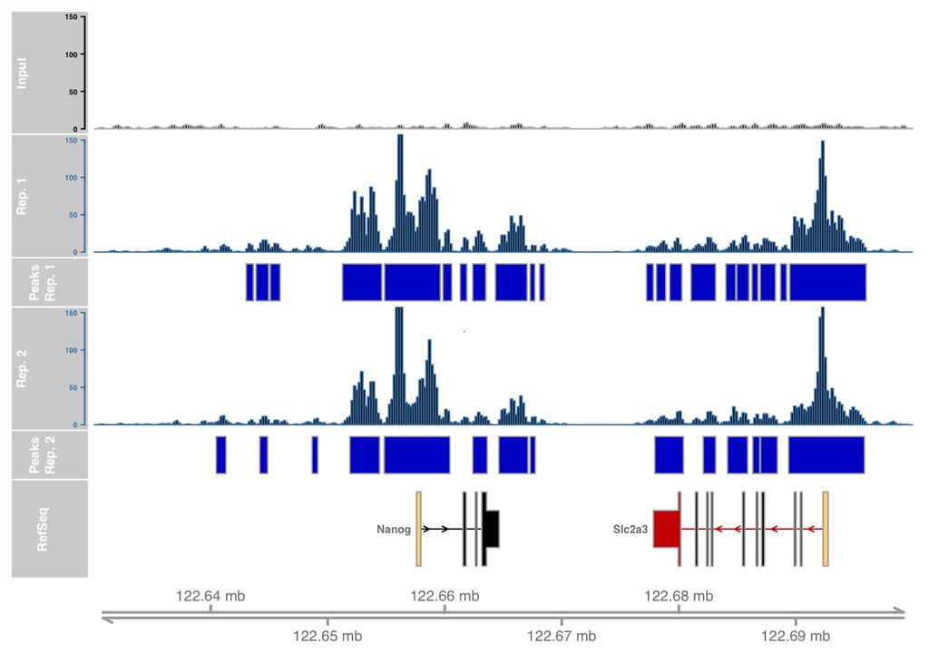

```r
plotTracks(c(input.track, rep1.track, peaks1.track,
             rep2.track, peaks2.track, bm, AT),
           from=122630000, to=122700000,
           transcriptAnnotation="symbol", window="auto",
           type="histogram", cex.title=0.7, fontsize=10 )
```

We can see that MACS has succesfully identified regions showing high H3K27ac signal. We see that both biological replicates agree well, however, in some cases peaks are called only in one sample. In the next section, we will analyse how often do we see the overlap between peaks and isolate reproducible peaks.

## 7.3 Venn diagrams

We first find the overlap between the peak sets of the two replicates.

```r
ovlp = findOverlaps( peaks.rep1, peaks.rep2 )
ovlp
```

```
## Hits object with 2528 hits and 0 metadata columns:
##          queryHits subjectHits
##          <integer>   <integer>
##      [1]         1           1
##      [2]         2           2
##      [3]         3           3
##      [4]         4           4
##      [5]         5           5
##      ...       ...         ...
##   [2524]      3025        3025
##   [2525]      3026        3026
##   [2526]      3029        3027
##   [2527]      3030        3028
##   [2528]      3031        3030
##   -------
##   queryLength: 3032 / subjectLength: 3032
```

If a peak in one replicate overlaps with mutiple peaks in the other replicate, it will appear multiple times in ovlp. To see, how many peaks overlap with something in the other replicate, we count the number of unique peaks in each of the two columns of ovlp and take the smaller of these two counts to as the number of common peaks.

```r
ov = min( length(unique( queryHits(ovlp) )), length(unique( subjectHits(ovlp) ) ) )
```

We draw this as a Venn diagram, using the draw.pairwise.venn function from the VennDiagram package.

```r
library(VennDiagram)
```

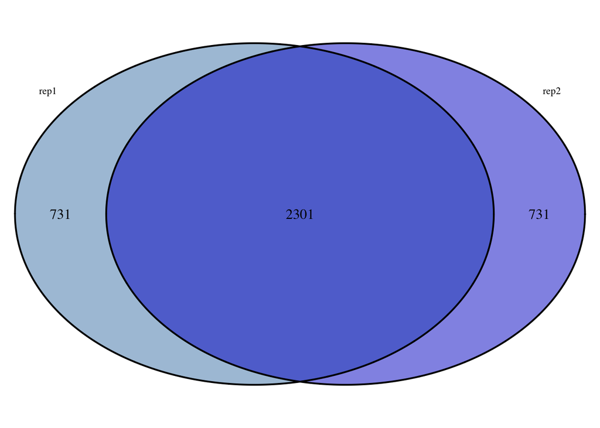

```
## (polygon[GRID.polygon.100], polygon[GRID.polygon.101], polygon[GRID.polygon.102], polygon[GRID.polygon.103], text[GRID.text.104], text[GRID.text.105], text[GRID.text.106], text[GRID.text.107], text[GRID.text.108])
```

```r
draw.pairwise.venn(
   area1=length(peaks.rep1),
   area2=length(peaks.rep2),
   cross.area=ov,
   category=c("rep1", "rep2"),
   fill=c("steelblue", "blue3"),
   cat.cex=0.7)
```

We will focus only on peaks identified in both replicates (hereafter refered to as enriched areas). The enriched areas are colored in green.

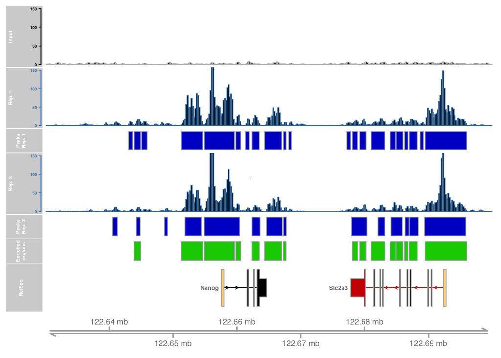

```r
enriched.regions = Reduce(subsetByOverlaps, list(peaks.rep1, peaks.rep2))

enr.reg.track = AnnotationTrack(enriched.regions,
                                genome="mm9", name='Enriched regions',
                                chromosome='chr6',
                                shape='box',fill='green3',size=2)

plotTracks(c(input.track, rep1.track, peaks1.track,
             rep2.track, peaks2.track, enr.reg.track,
             bm, AT),
           from=122630000, to=122700000,
           transcriptAnnotation="symbol", window="auto",
           type="histogram", cex.title=0.5, fontsize=10 )
```

## 7.4 Isolation of promoters overlapping H3K27ac peaks

One of the questions of a ChIP seq analyses is to which extend ChIP-enriched regions overlap a chosen type of features, such as promoters or regions enriched with other modifications. To this end, the overlap between peaks of ChIP-seq signal and the features of interest is analysed.

We exemplify such an analysis by testing how many of the H3K27ac enriched regions overlap promoter regions.

### 7.4.1 Identification of promoters

As shown in the Appendix, we have used biomaRt to get coordinates for start and end of all mouse genes. (These are the coordinates of the outermost UTR boundaries.) We load the results of the biomaRt query from the data package. It is given in the object egs, a data.frame containing ensembl ID along with gene symbols, genomic coordinates and orientation of of mouse genes.

```r
data(egs)
head(egs)
```

```
##      ensembl_gene_id external_gene_id chromosome_name start_position
## 1 ENSMUSG00000030270            Cpne9               6      113232301
## 2 ENSMUSG00000001632            Brpf1               6      113257175
## 3 ENSMUSG00000030271             Ogg1               6      113276966
## 4 ENSMUSG00000030272            Camk1               6      113284118
## 5 ENSMUSG00000048930            Tada3               6      113316019
## 6 ENSMUSG00000079426            Arpc4               6      113328107
##   end_position strand
## 1    113255621      1
## 2    113274851      1
## 3    113285062      1
## 4    113293978     -1
## 5    113327877     -1
## 6    113340442      1
```

We next identify the transcription start site (TSS), taking into account gene orientation.

```r
egs$TSS = ifelse( egs$strand == "1", egs$start_position, egs$end_position )
head(egs)
```

```
##      ensembl_gene_id external_gene_id chromosome_name start_position
## 1 ENSMUSG00000030270            Cpne9               6      113232301
## 2 ENSMUSG00000001632            Brpf1               6      113257175
## 3 ENSMUSG00000030271             Ogg1               6      113276966
## 4 ENSMUSG00000030272            Camk1               6      113284118
## 5 ENSMUSG00000048930            Tada3               6      113316019
## 6 ENSMUSG00000079426            Arpc4               6      113328107
##   end_position strand       TSS
## 1    113255621      1 113232301
## 2    113274851      1 113257175
## 3    113285062      1 113276966
## 4    113293978     -1 113293978
## 5    113327877     -1 113327877
## 6    113340442      1 113328107
```

```r
promoter_regions =
  GRanges(seqnames = Rle( paste0('chr', egs$chromosome_name) ),
          ranges = IRanges( start = egs$TSS - 200,
                            end = egs$TSS + 200 ),
          strand = Rle( rep("*", nrow(egs)) ),
          gene = egs$external_gene_id)
promoter_regions
```

```
## GRanges object with 1973 ranges and 1 metadata column:
##          seqnames                 ranges strand |        gene
##             <Rle>              <IRanges>  <Rle> | <character>
##      [1]     chr6 [113232101, 113232501]      * |       Cpne9
##      [2]     chr6 [113256975, 113257375]      * |       Brpf1
##      [3]     chr6 [113276766, 113277166]      * |        Ogg1
##      [4]     chr6 [113293778, 113294178]      * |       Camk1
##      [5]     chr6 [113327677, 113328077]      * |       Tada3
##      ...      ...                    ...    ... .         ...
##   [1969]     chr6 [ 30119537,  30119937]      * |      Mir183
##   [1970]     chr6 [ 93743566,  93743966]      * |          U6
##   [1971]     chr6 [116321886, 116322286]      * |     SNORA17
##   [1972]     chr6 [ 76150072,  76150472]      * |          U1
##   [1973]     chr6 [106951246, 106951646]      * |          U6
##   -------
##   seqinfo: 1 sequence from an unspecified genome; no seqlengths
```

### 7.4.2 Overlapping promoters with H3K27ac enriched regions

Now we would like to know how many of out the promoters overlap with a H3K27ac enriched regions.

```r
ovlp2 = findOverlaps( enriched.regions, promoter_regions )

cat(sprintf( "%d of %d promoters are overlapped by an enriched region.",
   length( unique(subjectHits(ovlp2)) ), length( promoter_regions ) ) )
```

```
## 634 of 1973 promoters are overlapped by an enriched region.
```

We can also turn the question around:

```r
ovlp2b = findOverlaps( promoter_regions, enriched.regions )

cat(sprintf( "%d of %d enriched regions overlap a promoter.",
   length( unique( subjectHits(ovlp2b) ) ), length( enriched.regions ) ) )
```

```
## 546 of 2301 enriched regions overlap a promoter.
```

Is this a significant enrichment? To see, we first calculate how much chromosome 6 is part of a promoter region. The following command reduces the promoter list to non-overlapping intervals and sums up their widths

```r
promotor_total_length = sum(width(reduce(promoter_regions)))
promotor_total_length
```

```
## [1] 766386
```

Which fraction of the chromsome is this?

```r
promotor_fraction_of_chromosome_6 = promotor_total_length / seqlengths(si)["chr6"]
```